# PML-Project

DK

8/10/2019

This is a project report to quantify how much of a particular exercise activity and how well it is done. The projet uses data from accelerometers on the belt, forearm, arm, and dumbell of 6 participants. The objective is to develop a cross-validated model and use it to predict 20 test cases.

CALLING FUNCTION LIBRARIES AND READING DATA INTO WORKSPACE

Library xlsx for reading data as an excel fine for easy viewing Library caret for the functions needed for building the predictive model

```r
library(xlsx)
library(caret)
```

Training data is the data to build the model, we assign it object “build_data”

Test data is used to make predictions using the model, we assign it object “test_data”

Mark all cells as “not available” if they have entries “NA” and “#DIV/0!”, or if they are empty

```r
build_data <- read.csv("pml-training.csv",na.strings=c("NA","#DIV/0!",""))
test_data <- read.csv("pml-testing.csv",na.strings=c("NA","#DIV/0!",""))
```

PREPROCESS THE MODEL BUILDING DATA

1 - Delete variables that are unlikely to affect the outcome

```r
var_delete = c("X","user_name","raw_timestamp_part_1","raw_timestamp_part_2","cvtd_timestamp", "new_window","num_window")
build_data <- build_data[, -which(names(build_data) %in% var_delete)]
```

2- Check status of variables that have “not available” data entries

```r
build_data_na <- build_data [, colSums(is.na(build_data)) > 0]
dim(build_data_na)
```

```
## [1] 19622   100
```

```r
dim(build_data)
```

```
## [1] 19622   153
```

The variables have no data collected and should be removed So include in the build data only those that do not have “not availabele” entries

```r
build_data <- build_data[, colSums(is.na(build_data)) == 0]
```

3- Remove variables that have very low levels of variability

```r
var_low <- nearZeroVar(build_data, freqCut = 95/5)

if(identical(var_low, integer(0)) == FALSE){
    build_data  <- build_data [, -var_low]
}
```

PREPROCESS THE MODEL TEST DATA PROVIDED

1 - Delete variables that are unlikely to affect the outcome

```r
var_delete = c("X", "user_name", "raw_timestamp_part_1", "raw_timestamp_part_2", "cvtd_timestamp", "new_window", "num_window")
test_data <- test_data[, -which(names(test_data) %in% var_delete)]
```

2- Remove columns/predictors that have “na”

```r
test_data <- test_data[, colSums(is.na(test_data)) == 0]
```

3- Remove variables that have very low levels of variability

```r
var_low <- nearZeroVar(test_data, freqCut = 10/1)

if(identical(var_low, integer(0)) == FALSE){
    test_data  <- test_data [, -var_low]
}
```

4 - Remove the last colum data and rename the column, “classe” as it is with the training data

```r
test_data$problem_id <- ""; colnames(test_data)[colnames(test_data)=="problem_id"] <- "classe"
test_data$classe <- as.factor(test_data$classe)
```

BUILD THE MODEL

To estimate out of sample error, we need a test data set, so we separate the model building data, i.e., in object, train_data into “training” and “testing” sets on a (60/40) basis

```r
set.seed(3225)
inTrain <- createDataPartition(y=build_data$classe, p=0.6, list=FALSE)
training <- build_data[inTrain,]
testing <- build_data[-inTrain,]
```

```r
ControlParameters <- trainControl(method="cv", number=8, repeats = 4, savePredictions = TRUE, classProbs = TRUE)
```

Build the model using the training data and assign it to object modelRF

```r
modelRF <- train(classe~., data=training, method="rf", trControl=ControlParameters)
```

Test the data on the testing data

```r
rf.predict <- predict(modelRF, testing)
```

The confusion matrix

```r
confusionMatrix(rf.predict, testing$classe)
```

```
## Confusion Matrix and Statistics
##
##           Reference
## Prediction    A    B    C    D    E
##          A 2230    9    0    0    0
##          B    1 1502   22    1    0
##          C    0    6 1339   21    2
##          D    1    1    7 1261    3
##          E    0    0    0    3 1437
##
## Overall Statistics
##
##                Accuracy : 0.9902
##                  95% CI : (0.9877, 0.9922)
##     No Information Rate : 0.2845
##     P-Value [Acc > NIR] : < 2.2e-16
##
##                   Kappa : 0.9876
##
##  Mcnemar's Test P-Value : NA
##
## Statistics by Class:
##
##                      Class: A Class: B Class: C Class: D Class: E
## Sensitivity            0.9991   0.9895   0.9788   0.9806   0.9965
## Specificity            0.9984   0.9962   0.9955   0.9982   0.9995
## Pos Pred Value         0.9960   0.9843   0.9788   0.9906   0.9979
## Neg Pred Value         0.9996   0.9975   0.9955   0.9962   0.9992
## Prevalence             0.2845   0.1935   0.1744   0.1639   0.1838
## Detection Rate         0.2842   0.1914   0.1707   0.1607   0.1832
## Detection Prevalence   0.2854   0.1945   0.1744   0.1622   0.1835
## Balanced Accuracy      0.9988   0.9928   0.9872   0.9894   0.9980
```

The cross validation graph

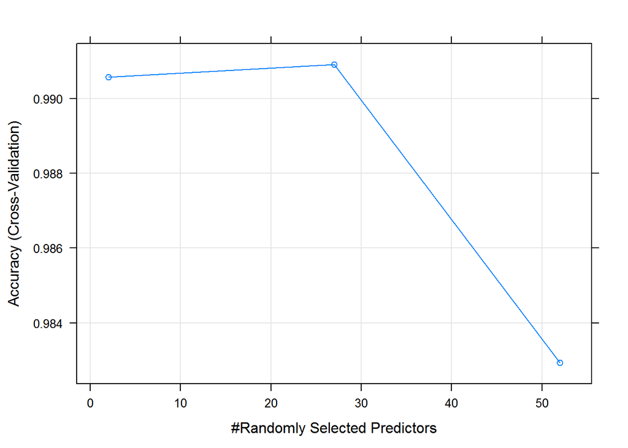

```r
plot(modelRF)
```

Plot the model

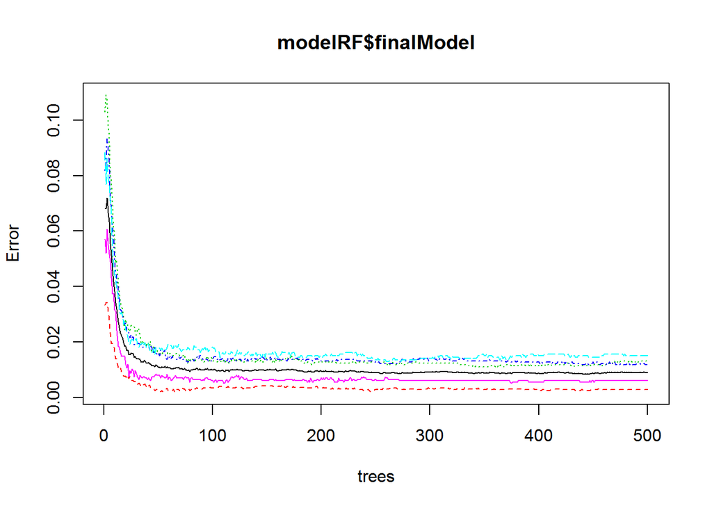

```r
plot(modelRF$finalModel)
```

Use the model to predict the classe in the originally uploaded 20 different test cases.

```r
predictions <- predict(modelRF, test_data)

predictions
```

```
##  [1] B A B A A E D B A A B C B A E E A B B B
## Levels: A B C D E
```